# Analyze A/B Test Results E-commerce website

# Introduction

## Should we choose the new page or the old page for our E-commerce website?

A/B tests are very commonly performed by data analysts and data scientists. For this project, we will be working to understand the results of an A/B test run by an e-commerce website. Our goal is to work through this notebook to help a company understand if they should:

### - Implement the new webpage,

### - Keep the old webpage, or

### - Perhaps run the experiment longer to make their decision.

# Dataset Overview

#### The dataset is composed of 294,478 entries containing different information like user id, the time user visited the website, the user group, landing page, and whether if they converted or not.

# Dataset summary statistics and proportions

```
Number of visitors in control group:  145274
Number of visitors in Treatment group:  145310
```

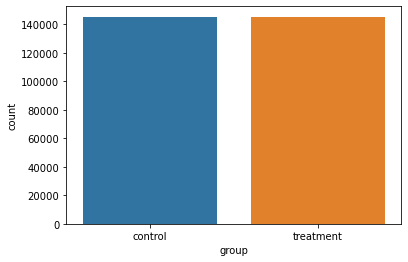

```python
sns.countplot(data=df2,x='group');
print("Number of visitors in control group: ",df2.query('group=="control"').shape[0])
print("Number of visitors in Treatment group: ",df2.query('group=="treatment"').shape[0])
```

#### What is probability of conversion regardless of the group?

```python
p_conv=df2['converted'].mean()
"{:.2%}".format(p_conv)
```

```
'11.96%'
```

#### Given that an individual was in the `control` group, what is the probability they converted?

```python
control_cr=df2.query('group=="control"')['converted'].mean()
"{:.2%}".format(control_cr)
```

```
'12.04%'
```

#### Given that an individual was in the `treatment` group, what is the probability they converted?

```python
treatment_cr=df2.query('group=="treatment"')['converted'].mean()
"{:.2%}".format(treatment_cr)
```

```
'11.88%'
```

#### What is the observed difference between the `new_page` conversions and `old_page` conversions in our **sample** dataset?

```python
# Calculate the actual difference (obs_diff) between the conversion rates for the two groups.
obs_diff=treatment_cr - control_cr
"{:.2%}".format(obs_diff)
```

```
'-0.16%'
```

# Do the `treatment` group users lead to more conversions?

### According to bayes theorem:

If we want to get whether the new `new_page` leads to more conversion rate or not, then we need to find the proportion of the `treatment` group in the conversion pool, in other words we need to calculate $P (treatment | converted) $

$$ P (treatment | converted) = \frac{P(treatment)P(converted | treatment )}{P(converted)} $$

$$ P (control | converted) = \frac{P(control)P(converted | control )}{P(converted)} $$

### And so the $P (treatment | converted) $ is:

```python
P_treatmeant_conv=p_treatment * treatment_cr / p_conv
"{:.2%}".format(P_treatmeant_conv)
```

```
'49.68%'
```

### And the $P (control | converted) $ is:

```python
P_control_conv=p_control * control_cr / p_conv
"{:.2%}".format(P_control_conv)
```

```
'50.32%'
```

#### It looks like the `old_page` leads to slightly more conversion than the `new_page`, however they are almost the same, In the next section we will attempt to calculate how significant is this observation from our sample and try to infer that to the actual population (**All the website users**)

# A/B Test

### Null Hypothesis $H_0$ Testing

Since the difference between the two conversion rates is **very small**. Lets assume that our null hypothesis $H_0$ that the `new_page` conversion rate $p_{new}$ is the same or lower than conversion rate of `old_page` $p_{old}$ until the oppoiste proves to be true. And so, our assumption is:

$$H_0: p_{new} \leq p_{old} $$$$H_1: p_{new} > p_{old} $$

### Which translates into:

$$ H_0: p_{new} - p_{old} \leq 0 $$$$ H_1: p_{new}-p_{old} > 0 $$

# Simulation

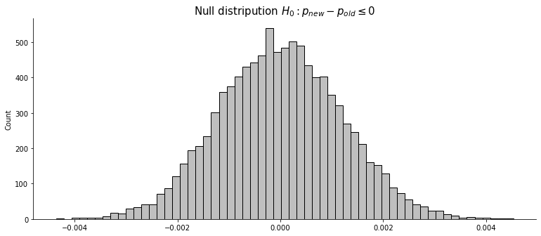

```python
null_dsprt=np.random.normal(0,np.std(p_diff),p_diff.size)
sns.displot(null_dsprt,color='#aaaaaa',height=4.5,aspect=2.4);
plt.title(r'Null distripution $ H_0: p_{new} - p_{old} \leq 0 $',fontsize=15);
```

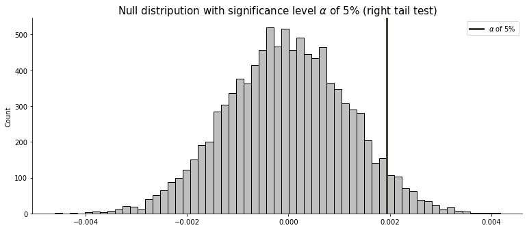

```python
null_dsprt=np.random.normal(0,np.std(p_diff),p_diff.size)
sns.displot(null_dsprt,color='#aaaaaa',height=4.5,aspect=2.4);
plt.axvline(np.percentile(null_dsprt,95),color='#3d4435',lw=3)
plt.title(r'Null distripution with significance level $\alpha$ of 5% (right tail test)',fontsize=15);
plt.legend(labels=[r'$\alpha$ of 5%']);
```

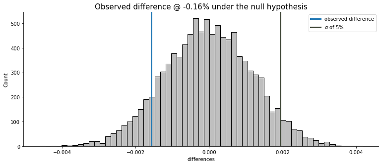

```python
obs="{:.2%}".format(obs_diff)
sns.displot(data=null,x='differences',color='#aaaaaa',height=4.5,aspect=2.4);
plt.axvline(obs_diff,lw=3)
plt.axvline(np.percentile(null_dsprt,95),color='#3d4435',lw=3)
plt.title('Observed difference @ {} under the null hypothesis'.format(obs),fontsize=15)
plt.legend(labels=['observed difference',r'$\alpha$ of 5%'],loc='upper right');
```

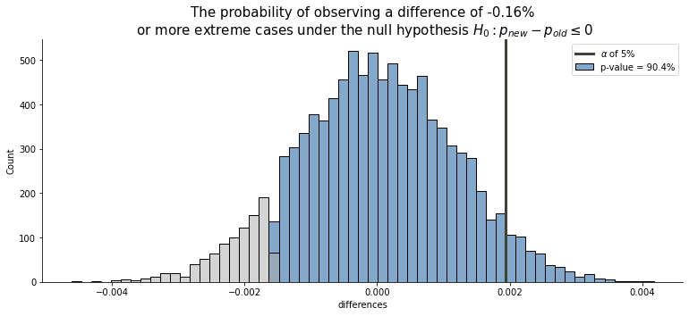

```python
null['p-value']=null['differences'].apply(lambda x: 1 if ((x > obs_diff)) else 0)
strin = 'The probability of observing a difference of {}\n or more extreme cases under the null hypothesis'.format(obs)
strin = strin + r" $ H_0: p_{new} - p_{old} \leq 0 $"
sns.displot(data=null,x='differences',hue='p-value',palette=['#aaaaaa','#0b5394'],legend=False,height=4.5,aspect=2.4);
plt.axvline(np.percentile(null_dsprt,95),color='#3d4435',lw=3)
plt.title(strin,fontsize=15);
plt.legend(labels=[r'$\alpha$ of 5%',"p-value = {:.1%}".format(null['p-value'].mean())],loc='upper right');
```

### And so our calculated p-value is

```python
"{:.2%}".format(null['p-value'].mean())
```

```
'90.42%'
```

#### - We fail to find enough evidence to reject the null hypothesis that we've assumed previously to be true stating that

#### - The conversion rate of the `new_page` is the same or lower than the conversion rate of the `old_page` $ H_0: p_{new} \leq p_{old} $

### So now we know for a fact that we can't favour the alternate hypothesis $ H_1: p_{new} > p_{old} $ over our null hypothesis $H_0: p_{new} \leq p_{old} $, we still have two question in mind.

#### However, $H_1: p_{new} \neq p_{old} $ can be translated into:

$$ p_{new} > p_{old} $$

#### or

$$ p_{new} < p_{old} $$

#### But we previously know from the right-tailed test that:

$$p_{new} \leq p_{old} $$

#### And this makes our current alternate hypothesis for the two-sided test should we reject the null:

$$ H_1: p_{new} < p_{old} $$

#### - **We fail to find enough evidence to reject the null hypothesis that we've assumed previously to be true stating that**

# Conclusion

#### - We fail to reject the null hypothesis $H_0: p_{new} = p_{old} $, there is no difference between old page and new page in terms of conversion.

#### - We should stick with the `old_page`,since we have no evidence for novelity effect or change aversion.